# 데이터 과학

펭귄 vs 붓꽃 데이터

[Tidyverse Korea](https://www.facebook.com/groups/tidyverse/)

2020-06-21

# 1 펭귄 데이터 출현[^1]

미국에서 “George Floyd”가 경찰에 의해 살해되면서 촉발된 [“Black Lives Matter”](https://ko.wikipedia.org/wiki/Black_Lives_Matter) 운동은 아프리카계 미국인을 향한 폭력과 제도적 인종주의에 반대하는 사회운동이다. 한국에서도 소수 정당인 정의당에서 [여당 의원 176명 중 누가?…차별금지법 발의할 ‘의인’을 구합니다](http://www.hani.co.kr/arti/politics/assembly/949422.html)로 기사로 낼 정도로 적극적으로 나서고 있다.

데이터 과학에서 최근 R.A. Fisher의 과거 저술한 “The genetical theory of natural selection” [1] 우생학(Eugenics) 대한 관점[^2]이 논란이 되면서 R 데이터 과학의 첫 데이터셋으로 붓꽃 `iris` 데이터를 다른 데이터, 즉 펭귄 데이터로 대체하는 움직임이 활발히 전개되고 있다. [`palmerpenguins`](https://github.com/allisonhorst/palmerpenguins) [2] 데이터셋이 대안으로 많은 호응을 얻고 있다.

## 1.1 펭귄 공부

팔머(Palmer) 펭귄은 3종이 있으며 자세한 내용은 다음 나무위키를 참조한다.[^3]

- [젠투 펭귄(Gentoo Penguin)](https://namu.wiki/w/젠투펭귄): 머리에 모자처럼 둘러져 있는 하얀 털 때문에 알아보기가 쉽다. 암컷이 회색이 뒤에, 흰색이 앞에 있다. 펭귄들 중에 가장 빠른 시속 36km의 수영 실력을 자랑하며, 짝짓기 할 준비가 된 펭귄은 75-90cm까지도 자란다.
- [아델리 펭귄(Adelie Penguin)](https://namu.wiki/w/아델리펭귄): 프랑스 탐험가인 뒤몽 뒤르빌(Dumont D’Urville) 부인의 이름을 따서 ‘아델리’라 불리게 되었다. 각진 머리와 작은 부리 때문에 알아보기 쉽고, 다른 펭귄들과 마찬가지로 암수가 비슷하게 생겼지만 암컷이 조금 더 작다.
- [턱끈 펭귄(Chinstrap Penguin)](https://namu.wiki/w/턱끈펭귄): 언뜻 보면 아델리 펭귄과 매우 비슷하지만, 몸집이 조금 더 작고, 목에서 머리 쪽으로 이어지는 검은 털이 눈에 띈다. 어린 고삐 펭귄들은 회갈색 빛을 띄는 털을 가지고 있으며, 목 아래 부분은 더 하얗다. 무리를 지어 살아가며 일부일처제를 지키기 때문에 짝짓기 이후에도 부부로써 오랫동안 함께 살아간다.

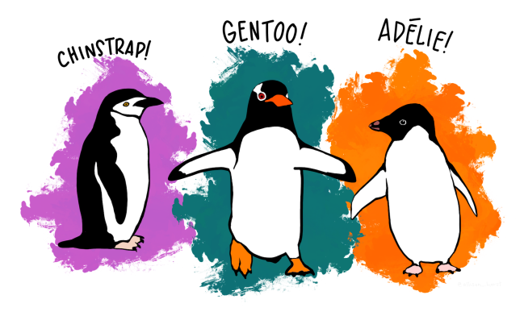

팔머 펭귄 3종 세트

```r
library(webshot)

webshot(url="https://allisonhorst.github.io/palmerpenguins/", selector = "#meet-the-palmer-penguins > p > img", "fig/penguin-species.png")
```

다음으로 `iris` 데이터와 마찬가지로 펭귄 3종을 구분하기 위한 변수로 조류의 부리에 있는 중앙 세로선의 융기를 지칭하는 능선(`culmen`) 길이(culmen length)와 깊이(culmen depth)를 이해하면 된다.

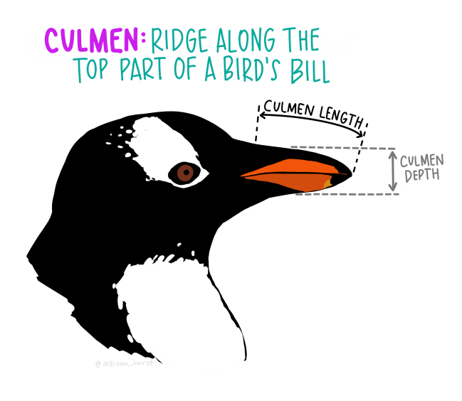

팔머 펭귄 능선 변수

```r
library(webshot)

webshot(url="https://allisonhorst.github.io/palmerpenguins/", selector = "#what-are-culmen-length--depth > p:nth-child(4) > img", "fig/penguin-species-variable.png")
```

## 1.2 펭귄 서식지

`leaflet` 팩키지로 펭귄 서식지를 남극에서 특정한다. `geocoding`을 해야 하는데 구글에서 위치 정보를 구글링하면 https://latitude.to/에서 직접 위경도를 반환하여 준다. 이 정보를 근거로 하여 펭귄 서식지를 시각화한다.

```r
library(tidyverse)
library(leaflet)
library(palmerpenguins)
# library(tidygeocoder)

penguins %>%
  count(island)
```

```
# A tibble: 3 x 2
  island        n
  <fct>     <int>
1 Biscoe      168
2 Dream       124
3 Torgersen    52
```

```r
island_df <- tribble(~"address", ~"lat", ~"lng",
                     "Torgersen Island antarctica", -64.7666636, -64.083333,
                     "Dream Island antarctica", -64.7333304, -64.2333324,
                     "Biscoe Island antarctica", -65.4333316, -65.499998,
                     "Palmer Station", -64.774167, -64.053056)

island_df %>%
  leaflet() %>%
  addProviderTiles(providers$OpenStreetMap) %>%
  addMarkers(lng=~lng, lat=~lat,
                   popup = ~ as.character(paste0("<strong>", paste0("명칭:",`address`), "</strong><br>",
                                                 "-----------------------------------------------------------<br>",
                                                 "&middot; latitude: ", `lat`, "<br>",
                                                 "&middot; longitude: ", `lng`, "<br>"
                   )))
```

[interactive chart not shown]

# 2 데이터 설치

`remotes` 팩키지 `install_github()` 함수로 펭귄 데이터를 설치한다.

```r
# install.packages("remotes")
remotes::install_github("allisonhorst/palmerpenguins")
```

`tidyverse` 팩키지 `glimpse()` 함수로 펭귄 데이터를 일별한다.

```r
library(tidyverse)
library(palmerpenguins)

glimpse(penguins)
```

```
Rows: 344
Columns: 7
$ species           <fct> Adelie, Adelie, Adelie, Adelie, Adelie, Adelie, A...
$ island            <fct> Torgersen, Torgersen, Torgersen, Torgersen, Torge...
$ bill_length_mm    <dbl> 39.1, 39.5, 40.3, NA, 36.7, 39.3, 38.9, 39.2, 34....
$ bill_depth_mm     <dbl> 18.7, 17.4, 18.0, NA, 19.3, 20.6, 17.8, 19.6, 18....
$ flipper_length_mm <int> 181, 186, 195, NA, 193, 190, 181, 195, 193, 190, ...
$ body_mass_g       <int> 3750, 3800, 3250, NA, 3450, 3650, 3625, 4675, 347...
$ sex               <fct> male, female, female, NA, female, male, female, m...
```

## 2.1 자료구조 일별

`skimr` 팩키지를 사용해서 `penguins` 데이터프레임 자료구조를 일별한다. 이를 통해서 344개 펭귄 관측값이 있으며, 7개 칼럼으로 구성된 것을 확인할 수 있다. 또한, 범주형 변수가 3개, 숫자형 변수가 4개로 구성되어 있다. 그외 더 자세한 사항은 범주형, 숫자형 변수에 대한 요약 통계량을 참조한다.

```r
skimr::skim(penguins)
```

Data summary

| Name | penguins |
| --- | --- |
| Number of rows | 344 |
| Number of columns | 7 |
| _______________________ |  |
| Column type frequency: |  |
| factor | 3 |
| numeric | 4 |
| ________________________ |  |
| Group variables | None |

**Variable type: factor**

| skim_variable | n_missing | complete_rate | ordered | n_unique | top_counts |
| --- | --- | --- | --- | --- | --- |
| species | 0 | 1.00 | FALSE | 3 | Ade: 152, Gen: 124, Chi: 68 |
| island | 0 | 1.00 | FALSE | 3 | Bis: 168, Dre: 124, Tor: 52 |
| sex | 11 | 0.97 | FALSE | 2 | mal: 168, fem: 165 |

**Variable type: numeric**

| skim_variable | n_missing | complete_rate | mean | sd | p0 | p25 | p50 | p75 | p100 | hist |
| --- | --- | --- | --- | --- | --- | --- | --- | --- | --- | --- |
| bill_length_mm | 2 | 0.99 | 43.92 | 5.46 | 32.1 | 39.23 | 44.45 | 48.5 | 59.6 | ▃▇▇▆▁ |
| bill_depth_mm | 2 | 0.99 | 17.15 | 1.97 | 13.1 | 15.60 | 17.30 | 18.7 | 21.5 | ▅▅▇▇▂ |
| flipper_length_mm | 2 | 0.99 | 200.92 | 14.06 | 172.0 | 190.00 | 197.00 | 213.0 | 231.0 | ▂▇▃▅▂ |
| body_mass_g | 2 | 0.99 | 4201.75 | 801.95 | 2700.0 | 3550.00 | 4050.00 | 4750.0 | 6300.0 | ▃▇▆▃▂ |

데이터가 크지 않아 `DT` 팩키지를 통해 데이터 전반적인 내용을 살펴볼 수 있다.

```r
penguins %>%
  DT::datatable()
```

|  | species | island | bill_length_mm | bill_depth_mm | flipper_length_mm | body_mass_g | sex |
| --- | --- | --- | --- | --- | --- | --- | --- |
| 1 | Adelie | Torgersen | 39.1 | 18.7 | 181 | 3750 | male |
| 2 | Adelie | Torgersen | 39.5 | 17.4 | 186 | 3800 | female |
| 3 | Adelie | Torgersen | 40.3 | 18 | 195 | 3250 | female |
| 4 | Adelie | Torgersen |  |  |  |  |  |
| 5 | Adelie | Torgersen | 36.7 | 19.3 | 193 | 3450 | female |
| 6 | Adelie | Torgersen | 39.3 | 20.6 | 190 | 3650 | male |
| 7 | Adelie | Torgersen | 38.9 | 17.8 | 181 | 3625 | female |
| 8 | Adelie | Torgersen | 39.2 | 19.6 | 195 | 4675 | male |
| 9 | Adelie | Torgersen | 34.1 | 18.1 | 193 | 3475 |  |
| 10 | Adelie | Torgersen | 42 | 20.2 | 190 | 4250 |  |

[output cut: 334 more lines]

# 3 탐색적 데이터 분석

`palmerpenguins` 데이터셋 소개에 포함되어 있는 미국 팔머 연구소 (palmer station) 펭귄 물갈퀴(flipper) 길이와 체질량(body mass) 산점도를 그려보자.

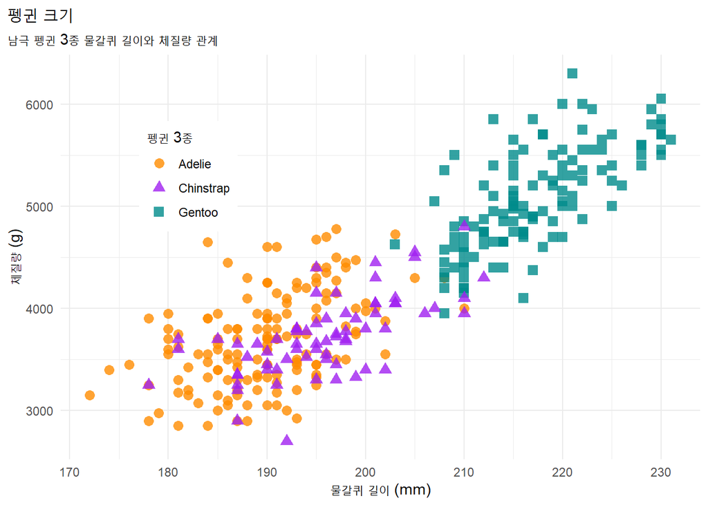

1. Fisher RA. The genetical theory of natural selection. Рипол Классик; 1958.

2. KB G, TD W, WR F. Ecological sexual dimorphism and environmental variability within a community of antarctic penguins (genus pygoscelis). PLoS ONE. 2014;9(3):–13. https://doi.org/10.1371/journal.pone.0090081.

[^1]: [AbdulMajedRaja RS (17 Jun 2020), "Penguins Dataset Overview - iris alternative in R using `palmerpenguins`](https://www.programmingwithr.com/penguins-dataset-overview-iris-alternative-in-r/)
[^2]: [IDO LEVY (DECEMBER 16, 2019), “EUGENICS AND THE ETHICS OF STATISTICAL ANALYSIS”, Goergetown Public Policy REview](http://gppreview.com/2019/12/16/eugenics-ethics-statistical-analysis/)
[^3]: [신발끈 여행사, 관광안내자료](http://www.shoestring.kr/shoecast/aaa/sp_01_peninsula/peninsula.html)